# Testscriptsimulations

Each ‘real association’ is simulated in the following manner:

Such that for every true associations a factor is chosen and ‘standardized’ such that the maximum value across the diagonal is one. The true effects are then simulated according to the assigned component, scaled by some factor $\omega$, and then and this scaling is added to a chosen mean for the gene, centered at o with $\sigma^{2}$ of 1.

The true $ceff$ is then computed as $ceff = \mu + \beta$

and $chat = ceff + E$ where E is simulated $N(0,V)$ and V is diagonal.

This function reports the true $\mu$, the true $\beta$ for the 1000 real genes and their associated componenent, as well as the standard error.

```r
chat_sim_fact
```

```
## function(n=1000,d=44,betasd=1,esd=0.1,K=10){
##   library("MASS")
##   library("mvtnorm")
##   J=0.10*n
##
##   configs = matrix((rnorm(d*K)),byrow=T,ncol=d) # A matrix of K classes (patterns) across R subgroups
##   F=as.matrix(configs);
##   covmat=lapply(seq(1:K),function(k){
##     A=F[k,]%*%t(F[k,]);
##     A/max(diag(A))})
##   ## each entry of F is the the factor of decomposition of covariance of effect sizes
##   z = sample(K,J,replace=TRUE) # randomly sample factor to be loaded on for each real snp
##
##
##   mus=rnorm(n)  ###generate a list of n mus
##   mumat=matrix(rep(mus,d),ncol=d)##generate a matrix of mus for each gene
##   omega=abs(rnorm(J,mean=0,sd=betasd))##effect size variance can be big or small
##   beta=t(sapply(seq(1:J),function(j){
##     k=z[j]
##     mvrnorm(1,mu=rep(0,d),Sigma=omega[j]*covmat[[k]])
##     #rmvnorm(1,mean = rep(0,d),sigma=omega*covmat[[k]])
##   }))
##
##   beta=rbind(beta,matrix(rep(0,(n-J)*d),ncol=d))
##   c=beta+mumat
##   sj=abs(matrix(rnorm(n*d,esd,0.001),ncol=d))##use uniform to simulate 'shrunken'
##   e=t(apply(sj,1,function(x){rmvnorm(1,mean=rep(0,d),sigma=diag(x)^2)}))
##   chat=c+e
##   t=chat/sj
##   return(list(beta=beta,chat=chat,covmat=covmat,components=z,t=t,mumat=mumat,shat=sj,error=e,ceff=c,F=F,omega=omega))
## }
## <environment: namespace:mash>
```

*Running*

Here, I want to show how to simulate and center. Recall that to center all t statistics, we need to use $t(L_{RxR}t(T_{JxR})$. I show how choosing those that have a maximum average deviation of at least 1 or a maximum deviation of at least 4 produces similar results:

```r
rm(list=ls())
library('mash')
set.seed(123)
RNGkind("Mersenne-Twister")
c=chat_sim_fact(n=10000,d=40,betasd=1,esd=0.1,K=10)

identical(c$beta[1,]+c$mumat[1,],c$ceff[1,])
```

```
## [1] TRUE
```

```r
identical(c$chat[1,],c$ceff[1,]+c$error[1,])
```

```
## [1] TRUE
```

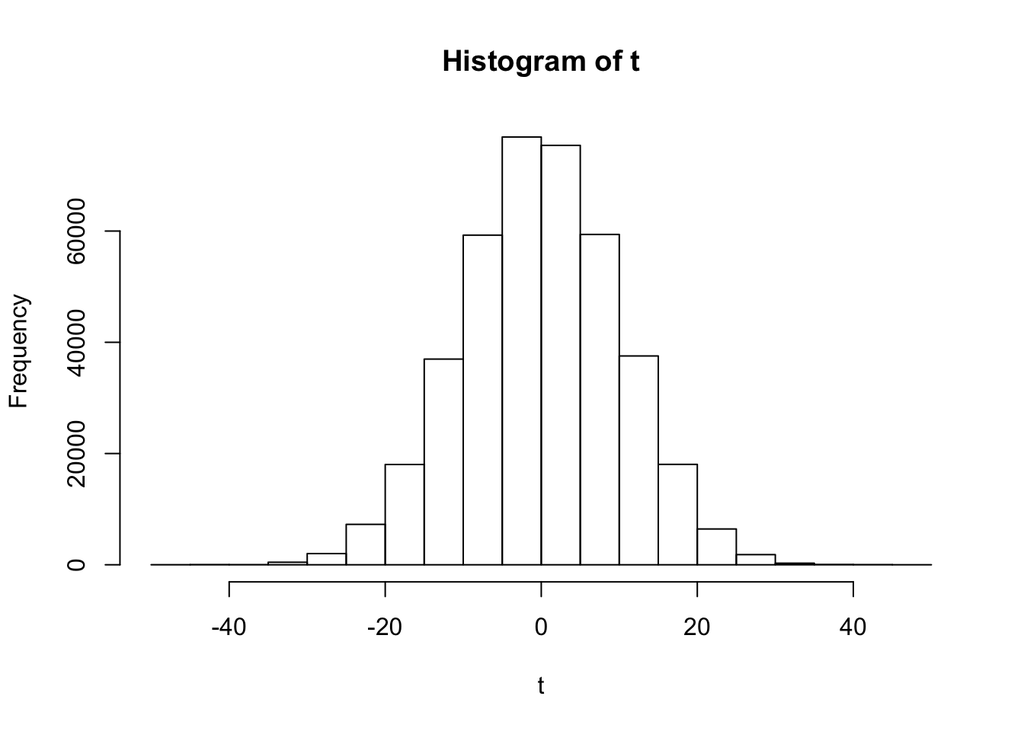

```r
saveRDS(c,"chatsimesd0.1.rds")
t=c$t;b=c$chat;se=c$shat
hist(t)
```

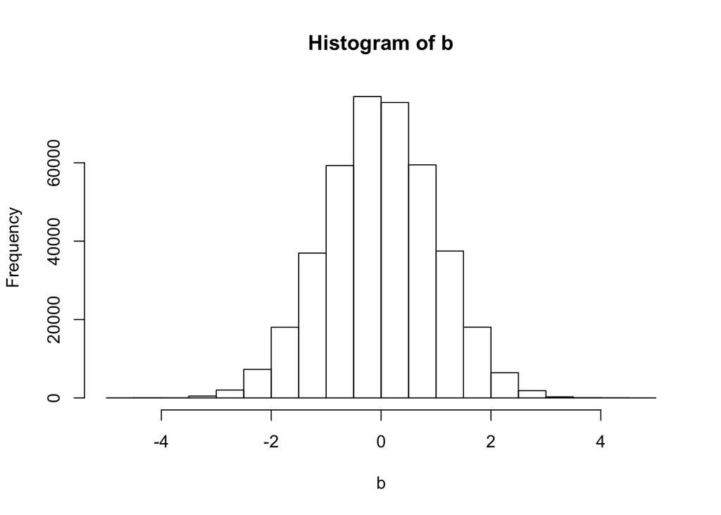

```r
hist(b)
```

```r
R=ncol(t)
L=diag(R)-1/R*as.vector(rep(1,R))%*%t(as.vector(rep(1,R)))
s.j=se/se

absmat=abs(t(L%*%t(c$t)))
index=which(rowMeans(absmat)>1.1)
length(index)
```

```
## [1] 737
```

```r
mean(index<1000)
```

```
## [1] 0.9810041
```

```r
index2=which(rowSums(absmat>4)>0)
mean(index2<1000)
```

```
## [1] 0.9664122
```

```r
length(index2)
```

```
## [1] 655
```

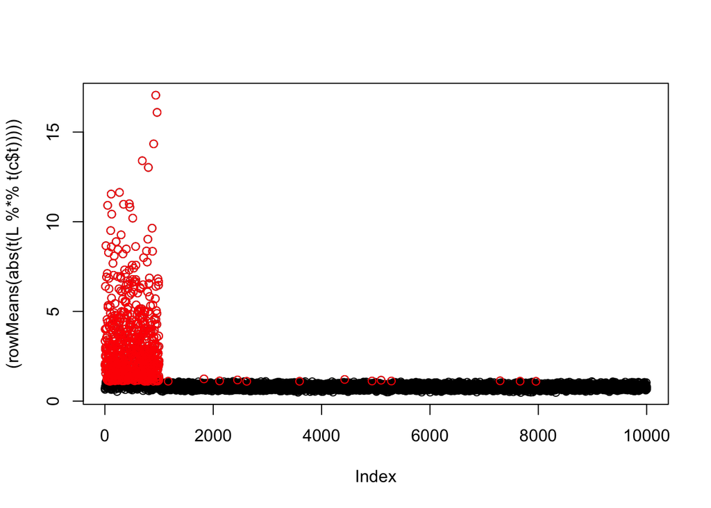

```r
#index=which(rowMeans(abs(t(L%*%t(c$t))))>1.3)##choose the associations with average deviation large.

##show median deviations
plot((rowMeans(abs(t(L%*%t(c$t))))))
points(index,(rowMeans(abs(t(L%*%t(c$t)))))[index],col="red")
```

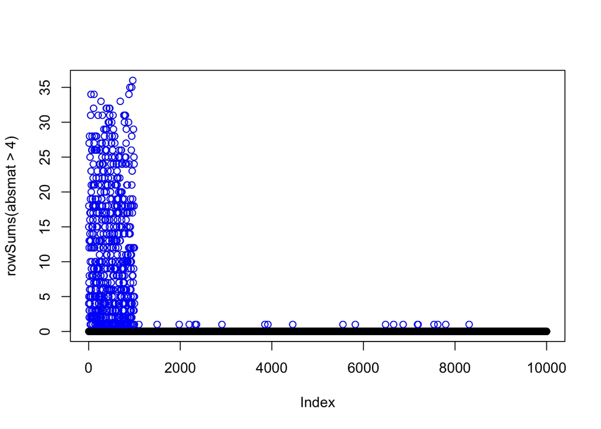

```r
plot(rowSums(absmat>4))
points(index2,rowSums(absmat>4)[index2],col="blue")
```

```r
strongprojectedtsimulations=t(L%*%t(t[index,]))



write.table(strongprojectedtsimulations,"strongprojectedtsimulations.txt",col.names = FALSE,row.names=FALSE)
```

Now, we need to project into the centered space to estimate the covariance matrix of the true deviations, using the full L since $v$ will be R, and not $R-1$.

```r
system('/Users/sarahurbut/miniconda3/bin/sfa -gen strongprojectedtsimulations.txt -g 737 -k 5 -n 40 i -o simulationsL')
A="simulationsL"

factor.mat=as.matrix(read.table("simulationsL_F.out"))
lambda.mat=as.matrix(read.table("simulationsL_lambda.out"))

#recall here that w will now be the L[-1,]%*%t(t[strong,]), which is equivalent to removing the first column of the strong projected t. Thus the covariance of v is initated with the RxR matrices (strong projected t), and the model is trained on the strong projected t less the first column because the model has v_{rxr}|w_{r,r-1}

strongprojectedt=strongprojectedtsimulations


lvllist=genlvllist(s.j[index,],L = L[-1,])


##w should represent transformed betahats using all R subgroups and j genes
wfull=t(L%*%t(b))
sjmat=convertstandarderrors(s.j = se,L=L)##make this be the standard errors of all, it is the sqrt of the diagonal of LVL' for each j. Recall here L is still RxR so we can have the full set of deviations and thier standard errors to choose grid
dim(wfull)
```

```
## [1] 10000    40
```

```r
dim(sjmat)
```

```
## [1] 10000    40
```

Now, first run ash. We have to run this separately because we have OpenMP conflicts.

```r
library("ashr")
ash.pm=matrix(NA,ncol=dim(wfull)[2],nrow=dim(wfull)[1])
ash.lfsr=matrix(NA,ncol=dim(wfull)[2],nrow=dim(wfull)[1])
for(i in 1:ncol(wfull)){

a=ash(betahat=wfull[,i],sebetahat=sjmat[,i],mixcompdist="normal")
ash.pm[,i]=a$PosteriorMean
ash.lfsr[,i]=a$lfsr
}
write.table(ash.pm,"ashmeans.txt")
write.table(ash.lfsr,"ashlfsr.txt")
```

Compute the likelihood without ED:

```r
A="noedcov"
noedcov=compute.covmat(b.gp.hat = wfull,sebetahat = sjmat,Q = 5,t.stat = strongprojectedt,lambda.mat = lambda.mat,P = 3,A = "noedcov",factor.mat = factor.mat,bma = T,zero = T,power = 2)$cov
```

Check that all the matrices are correctly computed:

```r
pca=svd(strongprojectedt);v=pca$v[,1:3];d=pca$d[1:3];u=pca$u[,1:3]
pcaprox=t(u%*%diag(d)%*%t(v))%*%(u%*%diag(d)%*%t(v))/max(diag(t(u%*%diag(d)%*%t(v))%*%(u%*%diag(d)%*%t(v))))


P=3;X.c=apply(strongprojectedt,2,function(x) x-mean(x)) ##Column centered matrix of t statistics
svd.X=svd(X.c)
M=nrow(X.c)
v=svd.X$v;u=svd.X$u;d=svd.X$d
cov.pc=1/M*v[,1:P]%*%diag(d[1:P])%*%t(u[,1:P])%*%t(v[,1:P]%*%diag(d[1:P])%*%t(u[,1:P]))

for(q in 1:5){
load=as.matrix(lambda.mat[,q])
fact=as.matrix(factor.mat[q,])
rank.prox=load%*%t(fact)
a=(1/(M-1)*(t(rank.prox)%*% rank.prox))/max(diag((1/(M-1)*(t(rank.prox)%*% rank.prox))))
print(all.equal(as.numeric(a),as.numeric(noedcov[[3+q]]/max(diag(noedcov[[3+q]])))))}
```

```
## [1] TRUE
## [1] TRUE
## [1] TRUE
## [1] TRUE
## [1] TRUE
```

```r
load=as.matrix(lambda.mat)
fact=as.matrix(factor.mat)
rank.prox=load%*%(fact)
a=(1/(M-1)*(t(rank.prox)%*% rank.prox))/max(diag((1/(M-1)*(t(rank.prox)%*% rank.prox))))
all.equal(as.numeric(a),as.numeric(noedcov[[9]]/max(diag(noedcov[[9]]))))
```

```
## [1] TRUE
```

```r
all.equal(cov(strongprojectedt)/max(diag(cov(strongprojectedt))),noedcov[[2]]/max(diag(noedcov[[2]])))
```

```
## [1] TRUE
```

```r
all.equal(as.numeric(cov.pc)/max(diag(cov.pc)),as.numeric(noedcov[[3]]/max(diag(noedcov[[3]]))))
```

```
## [1] TRUE
```

$Likelihood$

Now we will replace the RxR matrix $L$ with the $R-1xR$ matrix $L∗$, effectively removing a data point from the observed uncentered statistics, such that the rank of the marginal variance of $w$ is guaranteed to be equal to the dimension of $w$.

Now for each gene J at each component k, integrating over $\vb$,

$L_{R-1,R} \ceff \sim \Norm (0, L_{R-1,R} U_{k} L_{R-1,R} ')$ $L_{R-1,R} \chat \sim \Norm (0, L_{R-1,R} U_{k} L_{R-1,R} ' + L_{R-1,R} \hat{V} L_{R-1,R} ')$

And thus we can use the Bovy et al algorithm invoked in both the Extreme Deconvolution package and in `Sarah’s MixEm’ where the marginal variance at each component, $T_{jp}$:

$T_{jp} = L_{R-1,R} U_k L_{R-1,R}' + L_{R-1,R} \hat{V}_{j} L_{R-1,R}'$

For each gene, and $w_{j} = L_{R-1,R} \chat_{j}$.

Recall that our previous approach was simplified by the fact that $\bm{w}_{j}$ was simply $\hat{\bm{b}_{j}}$ and the projection matrix was simply the $I_{r}$ identity matrix. Our inference on $\bm{b}$ was analogous to their inference on $\vb_{j}$.

As before, we are interested in returning the prior covariance $U_k$ matrices of the `true` deviations $\vb$, which we will then rescale by choosing a set of $\omega$ that are appropriate to $L $ to comprise a set of $P = KxL$ prior covariance matrices $\Sigma$.

and choose the set of $\pi$ that maximizes compute the following likelihood at each of the P components:

$L_{R-1,R} \chat _j \sim \Norm (0, L_{R-1,R} \Sigma_{p} L_{R-1,R} ' + L_{R-1,R} \hat{V_j} L_{R-1,R} ')$

Now compute likelihood without ED:

```r
w=data.frame(wfull)[,-1]
compute.hm.train.log.lik.pen.with.L(w,se.train = se,covmat = noedcov,A = "noedcov",pen = 1,L = L[-1,])
```

```r
pis=readRDS(paste0("pis",A,".rds"))$pihat

likmat=readRDS(paste0("liketrain",A,".rds"))
test=exp(likmat)
sum(log(test%*%pis))
```

```
## [1] 348732.1
```

Now run with ED to show that 1) the likelihood improves 2) we have successfully implemented an approach which allows us to input a list of residual variance matrices (as opposed to a matrix of vectors to be diagonalised).

```r
rm(A)
rm(noedcov)
rm(pis)
library("ExtremeDeconvolution")
efunc=deconvolution.em.with.bovy.with.L(t.stat = strongprojectedt,factor.mat = factor.mat,lambda.mat = lambda.mat,v.j = lvllist,P = 3,L = L[-1,],Q = 5,w = strongprojectedt[,-1])

A="simulationsL"

max.step=efunc
edcov=compute.hm.covmat.all.max.step(b.hat = wfull,se.hat = sjmat,t.stat = strongprojectedt,Q = 5,lambda.mat = lambda.mat,A=A,factor.mat = factor.mat,max.step = efunc,zero = T,power = 2)$cov
length(edcov)
```

```
## [1] 1151
```

```r
w=data.frame(wfull)[,-1]

compute.hm.train.log.lik.pen.with.L(w,se.train = se,covmat = edcov,A = A,pen = 1,L = L[-1,])
```

```r
pis=readRDS(paste0("pis",A,".rds"))$pihat

likmat=readRDS(paste0("liketrain",A,".rds"))
test=exp(likmat)
sum(log(test%*%pis))
```

```
## [1] 352909.8
```

```r
for(j in 1:nrow(w)){
total.quant.per.snp.no.baseline(j = j,covmat = edcov,b.gp.hat = w,se.gp.hat = se,pis = pis,A = A,checkpoint = F,L = L[-1,])}
```

As you can see, the likelihood is much better with ED.

We can also compare our results to what we would get using the eqtlbma configs:

```r
rm(A)
A = "withbmaL"
covbma=compute.covmat.with.heterogeneity.no.shrink(b.gp.hat = wfull,sebetahat = sjmat,A = A,zero = T,power = 2 )


compute.hm.train.log.lik.pen.with.L(w,se.train = se,covmat = covbma,A = A,pen = 1,L = L[-1,])
```

```r
pis=readRDS(paste0("pis",A,".rds"))$pihat


for(j in 1:nrow(w)){
total.quant.per.snp.no.baseline(j = j,covmat = covbma,b.gp.hat = w,se.gp.hat = se,pis = pis,A = A,checkpoint = F,L = L[-1,])}
```

Compare RMSE and power:

```r
##now we read in computed means and lfsrs
bma.means=as.matrix(read.table("withbmaLposterior.means.txt")[,-1])
lfsr.bma=as.matrix(read.table("withbmaLlfsr.txt"))[,-1]
mash.means=as.matrix(read.table("simulationsLposterior.means.txt")[,-1])
lfsr.mash=as.matrix(read.table("simulationsLlfsr.txt"))[,-1]
ash.pm=as.matrix(read.table("ashmeans.txt"))
ash.lfsr=as.matrix(read.table("ashlfsr.txt"))
mle=as.matrix(wfull)
beta=as.matrix(c$beta)


standard=sqrt(mean((beta-mle)^2))
sqrt(mean((bma.means-beta)^2))/standard
```

```
## [1] 0.3404796
```

```r
sqrt(mean((mash.means-beta)^2))/standard
```

```
## [1] 0.2467874
```

```r
sqrt(mean((ash.pm-beta)^2))/standard
```

```
## [1] 0.4354056
```

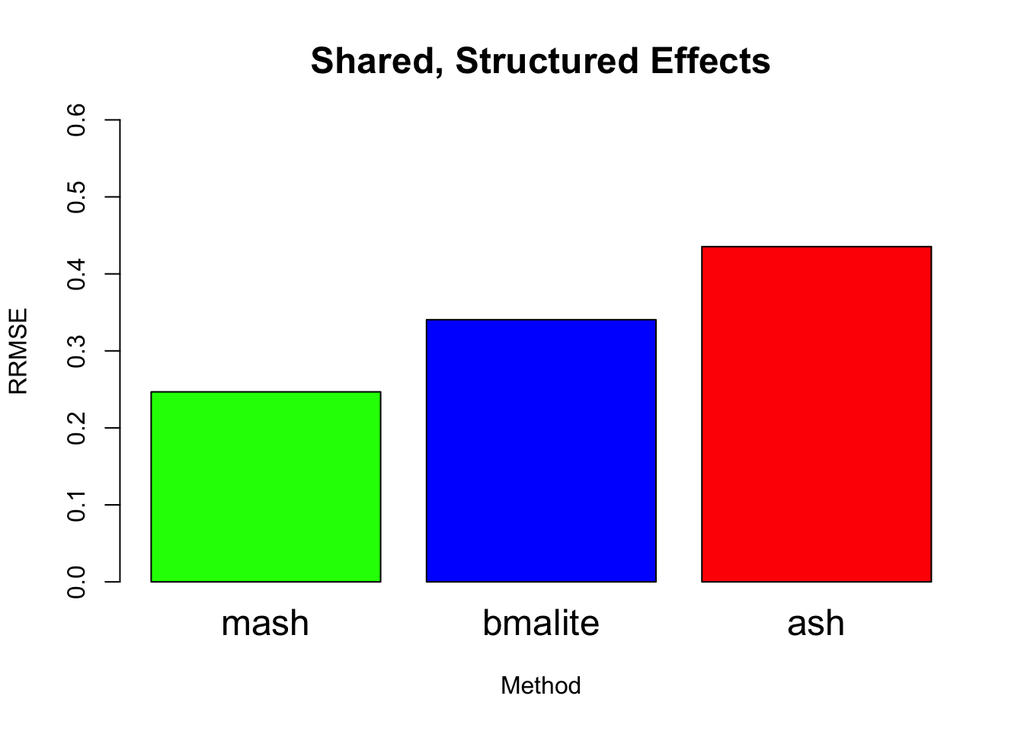

```r
rmse.all.table=cbind(mash=sqrt(mean((beta-mash.means)^2))/standard,bmalite=sqrt(mean((beta-bma.means)^2))/standard,ash=sqrt(mean((beta-ash.pm)^2))/standard)
barplot(as.numeric(rmse.all.table),main="Shared, Structured Effects",
        ylab="RRMSE",xlab="Method",col=c("green","blue","red"),names=colnames(rmse.all.table),ylim=c(0,0.6),cex.main=1.5,cex.lab=1,cex.names=1.5)
```

```r
sum(lfsr.mash<0.05)
```

```
## [1] 27217
```

```r
sum(lfsr.bma<0.05)
```

```
## [1] 1027
```

```r
sum(ash.lfsr<0.05)
```

```
## [1] 7850
```

Show ROC curves:

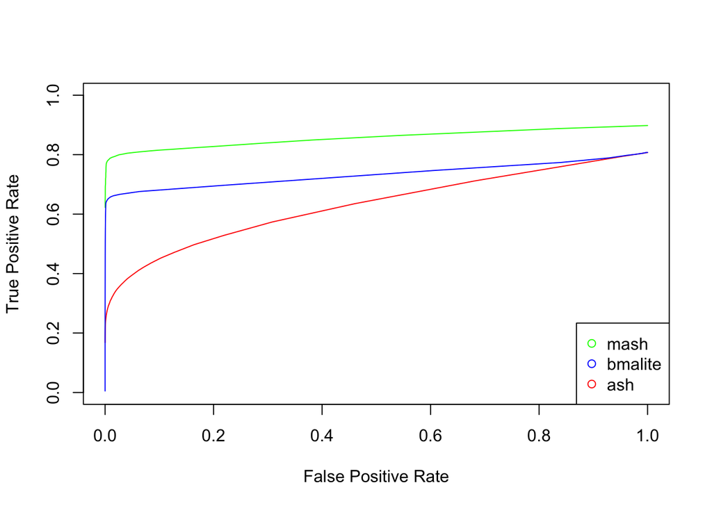

```r
##now we generate curves
mash.power=NULL
bma.power=NULL
ash.power=NULL

mash.fp=NULL
bma.fp=NULL
ash.fp=NULL

sign.test.mash=as.matrix(c$beta)*mash.means
sign.test.bma=as.matrix(c$beta)*bma.means
sign.test.ash=as.matrix(c$beta)*ash.pm
lfsr.ash=as.matrix(ash.lfsr)

thresholds=seq(0.01,1,by=0.01)
beta=as.matrix(c$beta)
for(s in 1:length(thresholds)){
thresh=thresholds[s]

##sign power is the proportion of true effects correctly signed at a given threshold
mash.power[s]=sum(sign.test.mash>0&lfsr.mash<=thresh)/sum(beta!=0)
bma.power[s]=sum(sign.test.bma>0&lfsr.bma<=thresh)/sum(beta!=0)
ash.power[s]=sum(sign.test.ash>0&lfsr.ash<=thresh)/sum(beta!=0)


##false positives is the proportion of null effects called at a given threshold
mash.fp[s]=sum(beta==0&lfsr.mash<=thresh)/sum(beta==0)
bma.fp[s]=sum(beta==0&lfsr.bma<=thresh)/sum(beta==0)
ash.fp[s]=sum(beta==0&lfsr.ash<=thresh)/sum(beta==0)

}





plot(mash.fp,mash.power,cex=0.5,pch=1,xlim=c(0,1),lwd=1,ylim=c(0,1),col="green",ylab="True Positive Rate",xlab="False Positive Rate",type="l",main="")
#title("True Positive vs False Positive",cex.main=1.5)
lines(ash.fp,ash.power,cex=0.5,pch=1,ylim=c(0,1),col="red")
lines(bma.fp,bma.power,cex=0.5,pch=1,ylim=c(0,1),col="blue")
legend("bottomright",legend = c("mash","bmalite","ash"),col=c("green","blue","red"),pch=c(1,1,1))
```

Test to show our calculations are accurate:

```r
mash.means=as.matrix(read.table("simulationsLposterior.means.txt")[,-1])
lfsr.mash=as.matrix(read.table("simulationsLlfsr.txt"))[,-1]
j=10
arrays=post.array.per.snp.no.baseline(j = 10,covmat = edcov,b.gp.hat = w,se.gp.hat = se,L = L[-1,])
k=5

V.gp.hat=diag(se[j,])^2

b.mle = as.vector(w[j,])

LSigL=L[-1,]%*%edcov[[k]]%*%t(L[-1,])
LVL=L[-1,]%*%V.gp.hat%*%t(L[-1,])

LSigL_list=lapply(edcov,function(x){L[-1,]%*%x%*%t(L[-1,])})
identical(LSigL_list[[k]],LSigL)
```

```
## [1] TRUE
```

```r
identical(as.numeric(arrays$post.means[k,]),as.numeric(post.mean.with.proj(b.mle = t(b.mle),tinv = solve(LVL+L[-1,]%*%edcov[[k]]%*%t(L[-1,])),U.k = edcov[[k]],L = L[-1,])))
```

```
## [1] TRUE
```

```r
identical(as.numeric(arrays$post.covs[k,]),as.numeric(diag(post.cov.with.proj(tinv = solve(LVL+L[-1,]%*%edcov[[k]]%*%t(L[-1,])),U.k = edcov[[k]],L = L[-1,]))))
```

```
## [1] TRUE
```

```r
log.lik.snp=log.lik.func(b.mle,LVL,LSigL_list)
log.lik.minus.max=log.lik.snp-max(log.lik.snp)
pis=readRDS("pissimulationsL.rds")$pihat
exp.vec=exp(log.lik.minus.max)
post.weights=t(exp.vec*pis/sum(exp.vec*pis))

all.equal(as.numeric(post.weights%*%arrays$post.means),as.numeric(mash.means[j,]))
```

```
## [1] TRUE
```

### COmpare with MASH

Now we can compare with mash. In this model, for each gene J:

$\chat |\mu, V = \mu + \beta + E$

$\chat - \mu = \beta + E$

and $E ~ N(0,V)$ while $\beta ~ \sum_{p} \pi_{p} N(0, U_{p})$

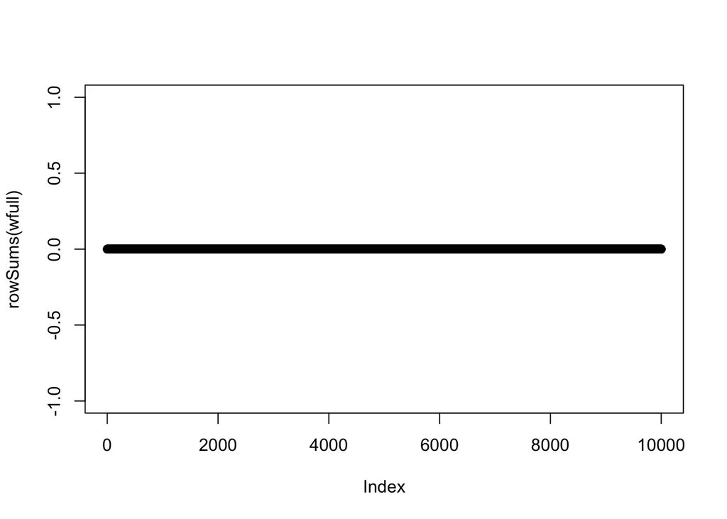

```r
rm(list=ls())
c=readRDS("chatsimesd0.1.rds")
t=c$t;b=c$chat;se=c$shat;R=ncol(t)
L=diag(R)-1/R*as.vector(rep(1,R))%*%t(as.vector(rep(1,R)))
wfull=t(L%*%t(b))
##show that they sum to 0

plot(rowSums(wfull),ylim=c(-1,1))
```

Now we proceed as in mash, selecting the strong t statistics:

```r
s.j=se/se
absmat=abs(t(L%*%t(c$t)))
index=which(rowMeans(absmat)>1.1)
length(index)
```

```
## [1] 737
```

```r
mean(index<1000)
```

```
## [1] 0.9810041
```

```r
factor.mat=as.matrix(read.table("simulationsL_F.out"))
lambda.mat=as.matrix(read.table("simulationsL_lambda.out"))


##choose the strong projected T and compute the max step##
##library("ExtremeDeconvolution")
strongprojectedtsimulations=t(L%*%t(t[index,]))
max.step=deconvolution.em.with.bovy(t.stat = strongprojectedtsimulations,factor.mat = factor.mat,v.j = s.j,lambda.mat = lambda.mat,K = 3,P = 3 )

##Show how the ranks is preserved
apply(max.step$true.covs,1,function(x){qr(x)$rank})
```

```
## [1] 39  5  3
```

```r
covmash=compute.hm.covmat.all.max.step(max.step = max.step,b.hat = wfull,se.hat = se,t.stat = strongprojectedtsimulations,Q = 5,lambda.mat = lambda.mat,A = "oldmashknit",factor.mat = factor.mat,zero = T,power = 2)$covmat

all.equal(covmash[[2]]/max(diag(covmash[[2]])),max.step$true.covs[1,,]/max(diag(max.step$true.covs[1,,])))
```

```
## [1] TRUE
```

```r
all.equal(covmash[[3]]/max(diag(covmash[[3]])),max.step$true.covs[3,,]/max(diag(max.step$true.covs[3,,])))
```

```
## [1] TRUE
```

```r
all.equal(covmash[[9]]/max(diag(covmash[[9]])),max.step$true.covs[2,,]/max(diag(max.step$true.covs[2,,])))
```

```
## [1] TRUE
```

Now, proceed as always, estimating likelihood and computing posteriors.

```r
A="oldmash"
compute.hm.train.log.lik.pen(train.b = wfull,se.train = se,covmat = covmash,A=A,pen=1)


pis=readRDS(paste0("pis",A,".rds"))$pihat
b.test=t
se.test=s.j
weightedquants=lapply(seq(1:nrow(wfull)),function(j){total.quant.per.snp(j,covmash,b.gp.hat=wfull,se.gp.hat = se,pis,A=A,checkpoint = FALSE)})
```

Test to show our calculations are accurate:

```r
mash.means=as.matrix(read.table("oldmashposterior.means.txt")[,-1])
lfsr.mash=as.matrix(read.table("oldmashlfsr.txt"))[,-1]
cov=readRDS("covmatoldmashknit.rds")
pis=readRDS("pisoldmash.rds")$pihat
w=data.frame(wfull)
j=10

arrays=post.array.per.snp.no.baseline(j = 10,covmat = cov,b.gp.hat = w,se.gp.hat = se,L = diag(1,40))
mash.arrays=post.array.per.snp(j = 10,covmat = cov,b.gp.hat = w,se.gp.hat = se)
##show same algebra


k=5

V.gp.hat=diag(se[j,])^2

b.mle = as.vector(w[j,])

lapply(seq(1:5),function(x){all.equal(arrays[[x]],mash.arrays[[x]])})
```

```
## [[1]]
## [1] TRUE
##
## [[2]]
## [1] TRUE
##
## [[3]]
## [1] TRUE
##
## [[4]]
## [1] TRUE
##
## [[5]]
## [1] TRUE
```

```r
L=diag(1,40)
LSigL=L%*%covmash[[k]]%*%t(L)
LVL=L%*%V.gp.hat%*%t(L)

LSigL_list=lapply(cov,function(x){L%*%x%*%t(L)})
identical(LSigL_list[[k]],LSigL)
```

```
## [1] TRUE
```

```r
identical(as.numeric(arrays$post.means[k,]),as.numeric(post.mean.with.proj(b.mle = t(b.mle),tinv = solve(LVL+L%*%cov[[k]]%*%t(L)),U.k = cov[[k]],L = L)))
```

```
## [1] TRUE
```

```r
identical(as.numeric(arrays$post.covs[k,]),as.numeric(diag(post.cov.with.proj(tinv = solve(LVL+L%*%cov[[k]]%*%t(L)),U.k = cov[[k]],L = L))))
```

```
## [1] TRUE
```

```r
log.lik.snp=log.lik.func(b.mle,LVL,LSigL_list)
log.lik.minus.max=log.lik.snp-max(log.lik.snp)
exp.vec=exp(log.lik.minus.max)
post.weights=t(exp.vec*pis/sum(exp.vec*pis))

all.equal(as.numeric(post.weights%*%arrays$post.means),as.numeric(mash.means[j,]))
```

```
## [1] TRUE
```

```r
mle=as.matrix(wfull)
beta=as.matrix(c$beta)

mash.nobaselinemeans=as.matrix(read.table("simulationsLposterior.means.txt")[,-1])
mash.means=as.matrix(read.table("oldmashposterior.means.txt")[,-1])


standard=sqrt(mean((beta-mle)^2))
sqrt(mean((mash.means-beta)^2))/standard
```

```
## [1] 0.2491109
```

```r
sqrt(mean((mash.nobaselinemeans-beta)^2))/standard
```

```
## [1] 0.2467874
```

As you can see, doesn’t ‘really’ reduce the RMSE.